# Preliminary Analysis of the OPTN/UNOS Data

Fan Wu

April 22, 2016

# Contents

- Dates in the UNOS Datasets
- Brief Summary of the Data
- Diabetes Types as a Risk Factor
- Interaction between Time on Dialysis and Diabetes

## Dates in the UNOS Datasets

There are several dates related to the transplant candidate/recipients defined in the waiting list dataset and the post-transplant follow-up dataset (the ones used to defind the event of interest are in **bold**).

- `DIALYSIS_DATE`: WL date of initiation of regularly administered dialysis for ESRD (WL);
- `ACTIVATE_DATE`: date when qualifying criteria were first entered (WL);
- `INIT_DATE`: date placed on the waiting list (WL);
- `ADMISSION_DATE`: recipient date of admission to the TX ctr (TRR);
- `TX_DATE`: **transplant date** (TRR);
- `DEATH_DATE`: date died for patients removed from the WL for reason of death (WL);
- `COMPOSITE_DEATH_DATE`: **composite patient death date** from OPTN/external sources (TRR/TRF-Calc);
- `END_DATE`: earliest date of removal from the WL (TX, D, or EOS) (WL);
- `FAIL_DATE_KI`: **graft fail date** - kidney (TRR/TRF-Calc);
- `GRF_FAIL_DATE`: date of graft failure (KIF);
- `PX_STAT_DATE`: recipient status date at time of FU (KIF).

TOC

## Brief Summary of the Data

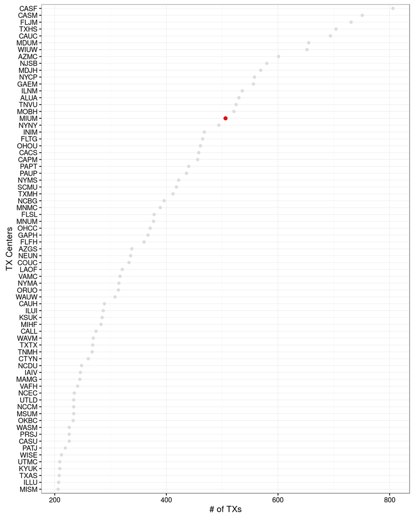

TOC

## Diabetes Types as a Risk Factor

The `DIAB` in the data are coded as follows:

- 1: No diabetes;
- 2: Type I diabetes;
- 3: Type II diabetes;
- 4: Unknown, Missing, Not Reported.

Within those centers with size $\geqslant$ 200, we also plot the % of diabetic patients (`DIAB = 2, 3, 4`) at TX.

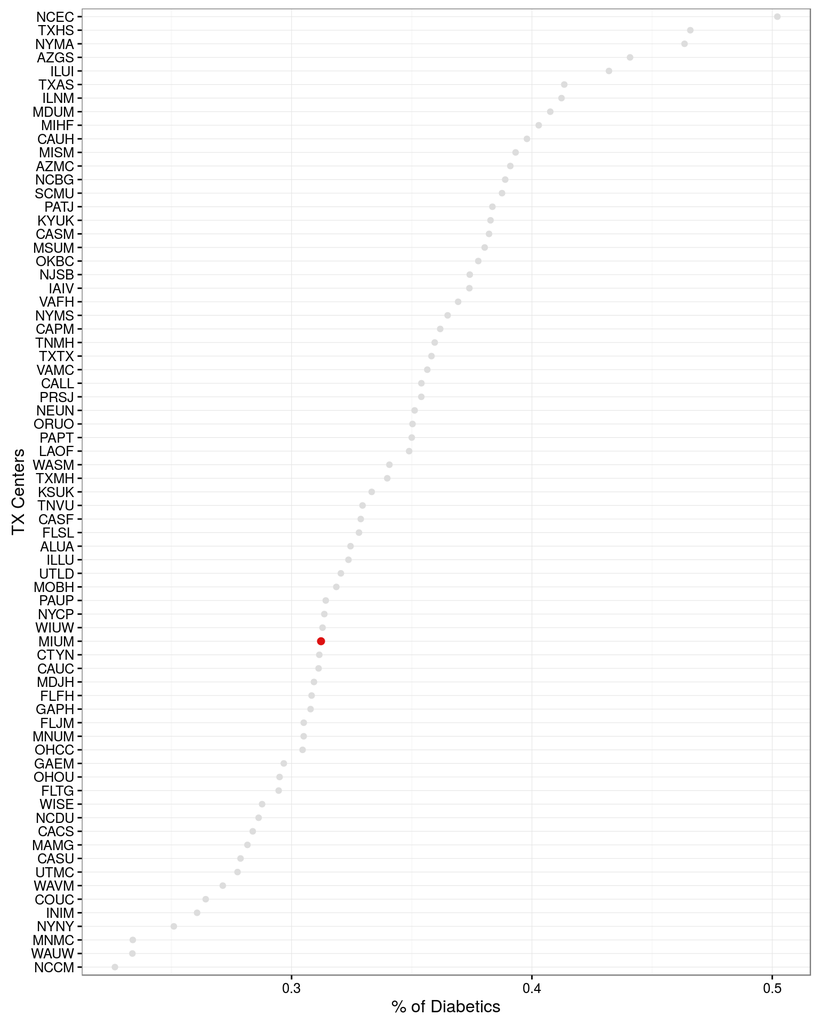

We first check cross table for diabetes types with one-year graft failure, one-year mortality, mean recipient age and % of PVD.

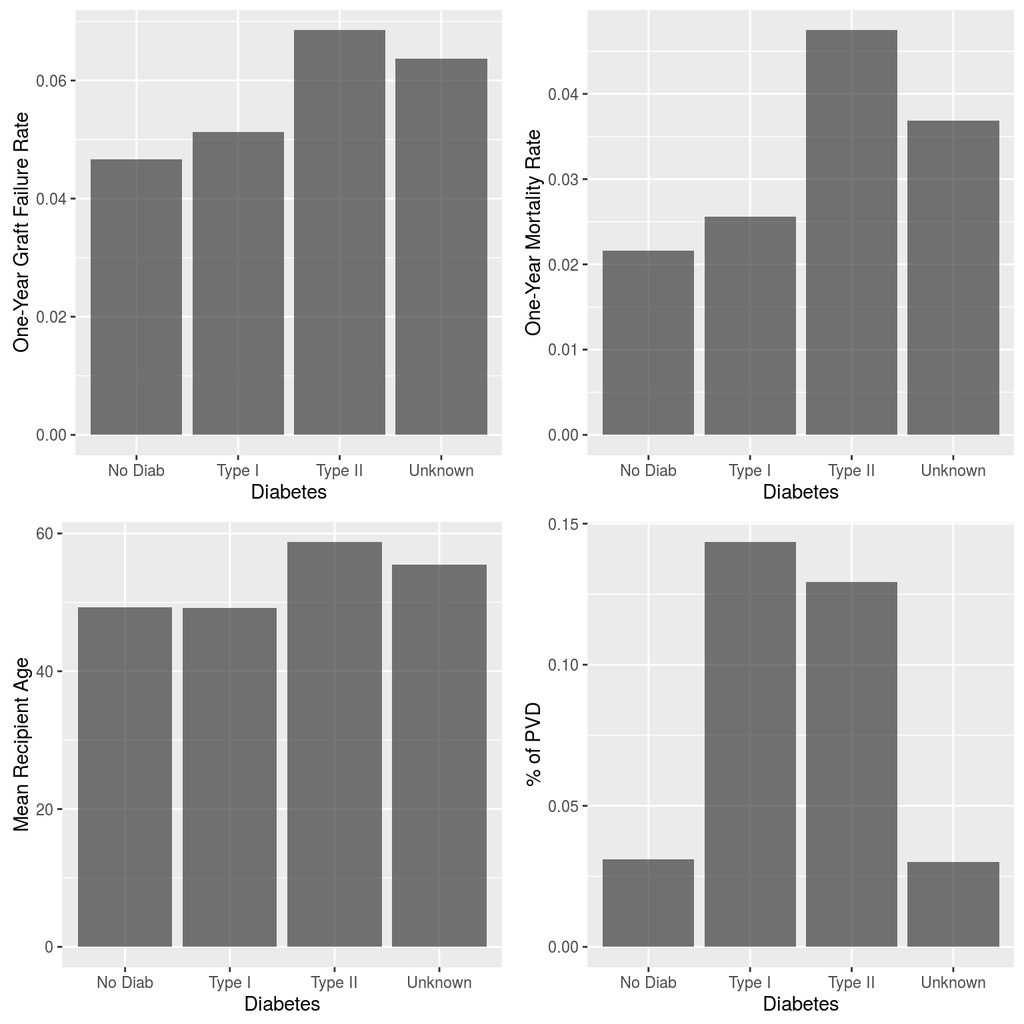

To check the effect of diabetes types on the graft failure rate and mortality rate by the time period after TX (3 mo, 3-6 mo, 6-12 mo).

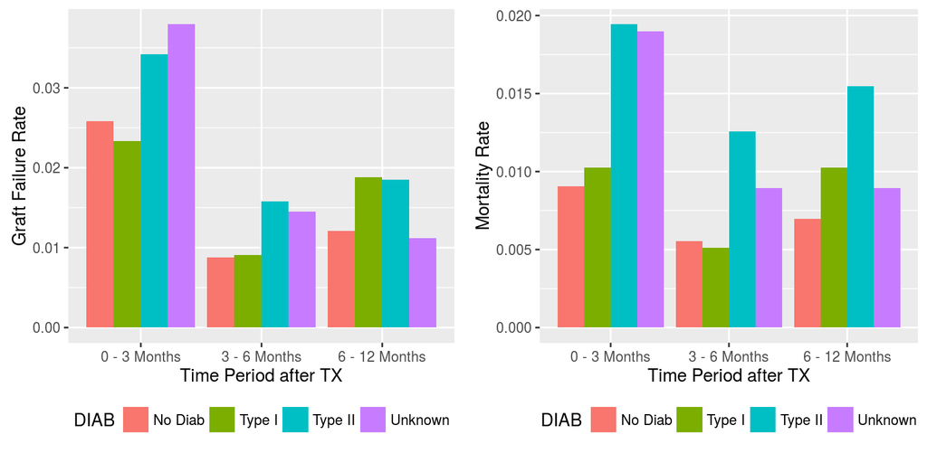

We then fit a stratified Cox model including all the risk factor listed as in our [plan](https://www-personal.umich.edu/~fannwu/SRTR/AnalysisPlan.docx) and using TX centers as the strata factor:

- Recipient: Age, race, sex, BMI, sensitization status (using cPRA), diabetes, peripheral vascular disease,
- Donor: Age, race, sex, BMI
- Transplantation: cold ischemia time, HLA mismatch ( 0-2,3-4, 5-6), type of organ (living versus deceased)

Separate models are fitted for graft (`T.GRF`) and patient (`T.PT`).

```
## Call:
## coxph(formula = Surv(T.GRF, D.GRF) ~ AGE + GENDER + ETHCAT +
##     DIAB + PERIP_VASC + BMI + AGE_DON + GENDER_DON + ETHCAT_DON +
##     BMI_DON + DON_TY + END_CPRA + COLD_ISCH_KI + HLAMISM + strata(TX_CTR),
##     data = unos)
##
##   n= 37863, number of events= 3116
##    (2534 observations deleted due to missingness)
##
##                              coef  exp(coef)   se(coef)       z Pr(>|z|)
## AGE                     0.0091103  1.0091519  0.0016399   5.556 2.77e-08 ***
## GENDERM                 0.0727265  1.0754364  0.0393403   1.849 0.064508 .
## ETHCATBlack            -0.0603201  0.9414632  0.0473281  -1.275 0.202484
## ETHCATHispanic         -0.4573741  0.6329435  0.0680093  -6.725 1.75e-11 ***
## ETHCATAsian            -0.4002765  0.6701348  0.0933650  -4.287 1.81e-05 ***
## ETHCATOther            -0.0103618  0.9896917  0.1455256  -0.071 0.943236
## DIABType I              0.1292692  1.1379964  0.0926794   1.395 0.163076
## DIABType II             0.1905650  1.2099330  0.0431092   4.421 9.85e-06 ***
## DIABUnknown             0.2116982  1.2357749  0.1201777   1.762 0.078147 .
## PERIP_VASCYes           0.3052176  1.3569203  0.0688456   4.433 9.28e-06 ***
## PERIP_VASCUnknown/Miss  0.3638457  1.4388522  0.1708775   2.129 0.033231 *
## BMINormal              -0.2282893  0.7958940  0.1357831  -1.681 0.092709 .
## BMIOverweight          -0.2448722  0.7828046  0.1356926  -1.805 0.071136 .
## BMIObese               -0.2693150  0.7639026  0.1357344  -1.984 0.047241 *
## AGE_DON                 0.0120627  1.0121358  0.0013604   8.867  < 2e-16 ***
## GENDER_DONM            -0.0242715  0.9760207  0.0375515  -0.646 0.518052
## ETHCAT_DONBlack         0.1526994  1.1649747  0.0532231   2.869 0.004117 **
## ETHCAT_DONHispanic      0.0681099  1.0704830  0.0593358   1.148 0.251021
## ETHCAT_DONAsian        -0.1054767  0.8998954  0.1259676  -0.837 0.402406
## ETHCAT_DONOther        -0.1090013  0.8967293  0.1743953  -0.625 0.531955
## BMI_DONNormal          -0.2952163  0.7443705  0.0946909  -3.118 0.001823 **
## BMI_DONOverweight      -0.3224613  0.7243639  0.0963628  -3.346 0.000819 ***
## BMI_DONObese           -0.2813595  0.7547570  0.0964880  -2.916 0.003545 **
## DON_TYL                -0.7619599  0.4667507  0.0666126 -11.439  < 2e-16 ***
## END_CPRA                0.0017053  1.0017067  0.0006004   2.840 0.004506 **
## COLD_ISCH_KI            0.0091690  1.0092111  0.0025179   3.642 0.000271 ***
## HLAMISM3-4              0.1658255  1.1803671  0.0595752   2.783 0.005378 **
## HLAMISM5-6              0.2035654  1.2257654  0.0601645   3.383 0.000716 ***
## ---
## Signif. codes:  0 '***' 0.001 '**' 0.01 '*' 0.05 '.' 0.1 ' ' 1
```

[output cut: 21 more lines]

```
## ETHCAT_DONOther           0.8967     1.1152    0.6371    1.2621
## BMI_DONNormal             0.7444     1.3434    0.6183    0.8962
## BMI_DONOverweight         0.7244     1.3805    0.5997    0.8749
## BMI_DONObese              0.7548     1.3249    0.6247    0.9119
## DON_TYL                   0.4668     2.1425    0.4096    0.5318
## END_CPRA                  1.0017     0.9983    1.0005    1.0029
## COLD_ISCH_KI              1.0092     0.9909    1.0042    1.0142
## HLAMISM3-4                1.1804     0.8472    1.0503    1.3266
## HLAMISM5-6                1.2258     0.8158    1.0894    1.3792
##
## Concordance= 0.655  (se = 0.057 )
## Rsquare= 0.02   (max possible= 0.559 )
## Likelihood ratio test= 759.6  on 28 df,   p=0
## Wald test            = 687.6  on 28 df,   p=0
## Score (logrank) test = 718.1  on 28 df,   p=0
```

```
## Call:
## coxph(formula = Surv(T.PT, D.PT) ~ AGE + GENDER + ETHCAT + DIAB +
##     PERIP_VASC + BMI + AGE_DON + GENDER_DON + ETHCAT_DON + BMI_DON +
##     DON_TY + END_CPRA + COLD_ISCH_KI + HLAMISM + strata(TX_CTR),
##     data = unos)
##
##   n= 37863, number of events= 1811
##    (2534 observations deleted due to missingness)
##
##                              coef  exp(coef)   se(coef)      z Pr(>|z|)
## AGE                     0.0386903  1.0394485  0.0023966 16.144  < 2e-16 ***
## GENDERM                 0.2127646  1.2370934  0.0534303  3.982 6.83e-05 ***
## ETHCATBlack            -0.2931450  0.7459140  0.0641596 -4.569 4.90e-06 ***
## ETHCATHispanic         -0.5826562  0.5584131  0.0900137 -6.473 9.61e-11 ***
## ETHCATAsian            -0.5990131  0.5493535  0.1256558 -4.767 1.87e-06 ***
## ETHCATOther            -0.0733450  0.9292802  0.1882942 -0.390 0.696889
## DIABType I              0.3301041  1.3911129  0.1231265  2.681 0.007340 **
## DIABType II             0.4538472  1.5743574  0.0549050  8.266  < 2e-16 ***
## DIABUnknown             0.4008468  1.4930886  0.1569011  2.555 0.010626 *
## PERIP_VASCYes           0.3034649  1.3545441  0.0865625  3.506 0.000455 ***
## PERIP_VASCUnknown/Miss  0.0267990  1.0271614  0.2434140  0.110 0.912333
## BMINormal              -0.4884934  0.6135501  0.1669128 -2.927 0.003426 **
## BMIOverweight          -0.6441839  0.5250909  0.1667124 -3.864 0.000112 ***
## BMIObese               -0.7102928  0.4915003  0.1669671 -4.254 2.10e-05 ***
## AGE_DON                 0.0101831  1.0102351  0.0017823  5.713 1.11e-08 ***
## GENDER_DONM             0.0578209  1.0595252  0.0497002  1.163 0.244669
## ETHCAT_DONBlack         0.1503631  1.1622562  0.0714689  2.104 0.035388 *
## ETHCAT_DONHispanic      0.0835642  1.0871550  0.0781932  1.069 0.285210
## ETHCAT_DONAsian         0.0323632  1.0328926  0.1620218  0.200 0.841679
## ETHCAT_DONOther         0.0879171  1.0918976  0.2190009  0.401 0.688092
## BMI_DONNormal          -0.1669343  0.8462552  0.1365059 -1.223 0.221364
## BMI_DONOverweight      -0.1451225  0.8649163  0.1380922 -1.051 0.293300
## BMI_DONObese           -0.1525592  0.8585080  0.1385727 -1.101 0.270926
## DON_TYL                -0.8638587  0.4215324  0.0896768 -9.633  < 2e-16 ***
## END_CPRA                0.0021540  1.0021564  0.0008232  2.617 0.008875 **
## COLD_ISCH_KI            0.0048072  1.0048188  0.0034249  1.404 0.160433
## HLAMISM3-4              0.0738666  1.0766632  0.0768541  0.961 0.336488
## HLAMISM5-6              0.0909964  1.0952651  0.0778420  1.169 0.242409
## ---
## Signif. codes:  0 '***' 0.001 '**' 0.01 '*' 0.05 '.' 0.1 ' ' 1
```

[output cut: 21 more lines]

```
## ETHCAT_DONOther           1.0919     0.9158    0.7108    1.6772
## BMI_DONNormal             0.8463     1.1817    0.6476    1.1058
## BMI_DONOverweight         0.8649     1.1562    0.6598    1.1338
## BMI_DONObese              0.8585     1.1648    0.6543    1.1264
## DON_TYL                   0.4215     2.3723    0.3536    0.5025
## END_CPRA                  1.0022     0.9978    1.0005    1.0038
## COLD_ISCH_KI              1.0048     0.9952    0.9981    1.0116
## HLAMISM3-4                1.0767     0.9288    0.9261    1.2517
## HLAMISM5-6                1.0953     0.9130    0.9403    1.2758
##
## Concordance= 0.725  (se = 0.076 )
## Rsquare= 0.027   (max possible= 0.372 )
## Likelihood ratio test= 1034  on 28 df,   p=0
## Wald test            = 890.8  on 28 df,   p=0
## Score (logrank) test = 954.7  on 28 df,   p=0
```

## Interaction between Time on Dialysis and Diabetes

We first check the cross table between diabetes types and the dialysis time (pre-emptive: no dialysis recorded; 0-2 years, 2-4 years and 4 years+). The density plot of the exact time on dialysis is also plotted.

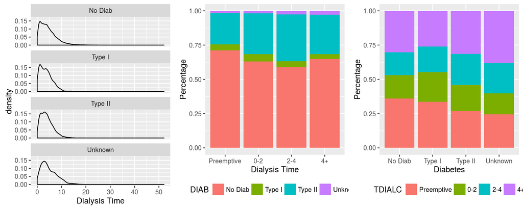

Then we inspect the one-year graft failure rate and the mortality rate for different combination of dialysis time and diabetes types.

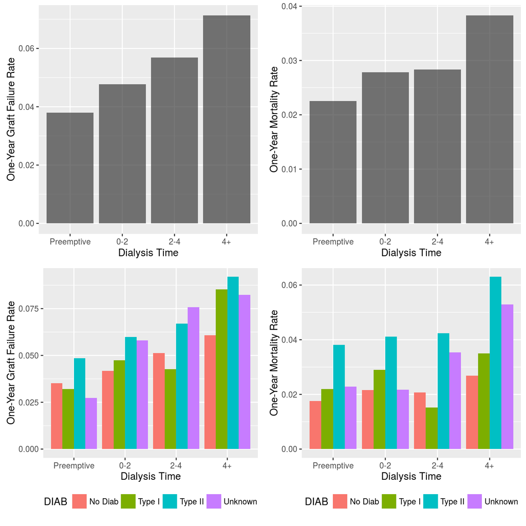

```
## Call:
## coxph(formula = Surv(T.GRF, D.GRF) ~ AGE + GENDER + ETHCAT +
##     DIAB * TDIALC + PERIP_VASC + BMI + AGE_DON + GENDER_DON +
##     ETHCAT_DON + BMI_DON + DON_TY + END_CPRA + COLD_ISCH_KI +
##     HLAMISM + strata(TX_CTR), data = unos)
##
##   n= 37863, number of events= 3116
##    (2534 observations deleted due to missingness)
##
##                              coef  exp(coef)   se(coef)      z Pr(>|z|)
## AGE                     0.0101114  1.0101627  0.0016449  6.147 7.88e-10 ***
## GENDERM                 0.0618208  1.0637717  0.0394025  1.569 0.116658
## ETHCATBlack            -0.1246688  0.8827893  0.0483730 -2.577 0.009959 **
## ETHCATHispanic         -0.5151376  0.5974184  0.0683892 -7.532 4.98e-14 ***
## ETHCATAsian            -0.4290672  0.6511162  0.0935085 -4.589 4.46e-06 ***
## ETHCATOther            -0.0847516  0.9187405  0.1463212 -0.579 0.562443
## DIABType I              0.0941909  1.0987695  0.1901513  0.495 0.620355
## DIABType II             0.0642766  1.0663874  0.0876833  0.733 0.463525
## DIABUnknown             0.0126298  1.0127098  0.2623210  0.048 0.961600
## TDIALC0-2               0.2712121  1.3115532  0.0791154  3.428 0.000608 ***
## TDIALC2-4               0.2263156  1.2539713  0.0741914  3.050 0.002285 **
## TDIALC4+                0.3196705  1.3766741  0.0646139  4.947 7.52e-07 ***
## PERIP_VASCYes           0.2693669  1.3091354  0.0689924  3.904 9.45e-05 ***
## PERIP_VASCUnknown/Miss  0.3814853  1.4644581  0.1713101  2.227 0.025956 *
## BMINormal              -0.2141460  0.8072305  0.1358666 -1.576 0.114991
## BMIOverweight          -0.2302868  0.7943058  0.1357980 -1.696 0.089923 .
## BMIObese               -0.2551902  0.7747691  0.1358469 -1.879 0.060311 .
## AGE_DON                 0.0117665  1.0118360  0.0013631  8.632  < 2e-16 ***
## GENDER_DONM            -0.0250964  0.9752159  0.0375747 -0.668 0.504193
## ETHCAT_DONBlack         0.1487242  1.1603529  0.0532535  2.793 0.005226 **
## ETHCAT_DONHispanic      0.0634000  1.0654529  0.0593014  1.069 0.285018
## ETHCAT_DONAsian        -0.1088502  0.8968647  0.1259306 -0.864 0.387386
## ETHCAT_DONOther        -0.1129493  0.8931960  0.1743021 -0.648 0.516979
## BMI_DONNormal          -0.2944927  0.7449094  0.0946640 -3.111 0.001865 **
## BMI_DONOverweight      -0.3203166  0.7259192  0.0963394 -3.325 0.000885 ***
## BMI_DONObese           -0.2764035  0.7585068  0.0964632 -2.865 0.004165 **
## DON_TYL                -0.6782018  0.5075288  0.0690874 -9.817  < 2e-16 ***
## END_CPRA                0.0016050  1.0016063  0.0006008  2.671 0.007553 **
## COLD_ISCH_KI            0.0088677  1.0089071  0.0025194  3.520 0.000432 ***
## HLAMISM3-4              0.1519943  1.1641535  0.0598184  2.541 0.011056 *
```

[output cut: 45 more lines]

```
## DIABType I:TDIALC0-2      1.0544     0.9484    0.6010    1.8498
## DIABType II:TDIALC0-2     1.0416     0.9600    0.8041    1.3493
## DIABUnknown:TDIALC0-2     1.4293     0.6996    0.6684    3.0563
## DIABType I:TDIALC2-4      0.8786     1.1381    0.5022    1.5373
## DIABType II:TDIALC2-4     1.0907     0.9168    0.8626    1.3791
## DIABUnknown:TDIALC2-4     1.5910     0.6286    0.8208    3.0836
## DIABType I:TDIALC4+       1.1146     0.8972    0.6995    1.7759
## DIABType II:TDIALC4+      1.2534     0.7978    1.0196    1.5409
## DIABUnknown:TDIALC4+      1.1193     0.8934    0.6104    2.0524
##
## Concordance= 0.66  (se = 0.057 )
## Rsquare= 0.022   (max possible= 0.559 )
## Likelihood ratio test= 832.1  on 40 df,   p=0
## Wald test            = 764  on 40 df,   p=0
## Score (logrank) test = 802.9  on 40 df,   p=0
```

```
## Call:
## coxph(formula = Surv(T.PT, D.PT) ~ AGE + GENDER + ETHCAT + DIAB *
##     TDIALC + PERIP_VASC + BMI + AGE_DON + GENDER_DON + ETHCAT_DON +
##     BMI_DON + DON_TY + END_CPRA + COLD_ISCH_KI + HLAMISM + strata(TX_CTR),
##     data = unos)
##
##   n= 37863, number of events= 1811
##    (2534 observations deleted due to missingness)
##
##                              coef  exp(coef)   se(coef)      z Pr(>|z|)
## AGE                     0.0397639  1.0405651  0.0024042 16.540  < 2e-16 ***
## GENDERM                 0.2064992  1.2293668  0.0535423  3.857 0.000115 ***
## ETHCATBlack            -0.3700076  0.6907290  0.0654828 -5.650 1.60e-08 ***
## ETHCATHispanic         -0.6518191  0.5210970  0.0905401 -7.199 6.06e-13 ***
## ETHCATAsian            -0.6338673  0.5305361  0.1259280 -5.034 4.81e-07 ***
## ETHCATOther            -0.1637927  0.8489180  0.1897443 -0.863 0.388012
## DIABType I              0.2810280  1.3244907  0.2410038  1.166 0.243585
## DIABType II             0.2655741  1.3041795  0.1077734  2.464 0.013732 *
## DIABUnknown             0.2999843  1.3498377  0.3193497  0.939 0.347546
## TDIALC0-2               0.1991685  1.2203876  0.1113254  1.789 0.073604 .
## TDIALC2-4               0.0693725  1.0718354  0.1055539  0.657 0.511037
## TDIALC4+                0.3264058  1.3859777  0.0889207  3.671 0.000242 ***
## PERIP_VASCYes           0.2607286  1.2978753  0.0868504  3.002 0.002682 **
## PERIP_VASCUnknown/Miss  0.0020896  1.0020918  0.2441158  0.009 0.993170
## BMINormal              -0.4721065  0.6236871  0.1672068 -2.823 0.004750 **
## BMIOverweight          -0.6269514  0.5342179  0.1670883 -3.752 0.000175 ***
## BMIObese               -0.6942918  0.4994280  0.1673374 -4.149 3.34e-05 ***
## AGE_DON                 0.0098230  1.0098714  0.0017893  5.490 4.02e-08 ***
## GENDER_DONM             0.0580511  1.0597691  0.0497510  1.167 0.243278
## ETHCAT_DONBlack         0.1480176  1.1595334  0.0715100  2.070 0.038463 *
## ETHCAT_DONHispanic      0.0794687  1.0827116  0.0781519  1.017 0.309225
## ETHCAT_DONAsian         0.0317165  1.0322249  0.1619569  0.196 0.844741
## ETHCAT_DONOther         0.0696645  1.0721484  0.2187812  0.318 0.750166
## BMI_DONNormal          -0.1668297  0.8463438  0.1364484 -1.223 0.221459
## BMI_DONOverweight      -0.1405877  0.8688474  0.1380534 -1.018 0.308508
## BMI_DONObese           -0.1471973  0.8631236  0.1385233 -1.063 0.287955
## DON_TYL                -0.7628061  0.4663559  0.0927349 -8.226 2.22e-16 ***
## END_CPRA                0.0020499  1.0020520  0.0008247  2.486 0.012928 *
## COLD_ISCH_KI            0.0044975  1.0045077  0.0034267  1.312 0.189354
## HLAMISM3-4              0.0512851  1.0526230  0.0772191  0.664 0.506594
```

[output cut: 45 more lines]

```
## DIABType I:TDIALC0-2      1.3969     0.7159    0.6959    2.8039
## DIABType II:TDIALC0-2     1.0999     0.9092    0.7921    1.5274
## DIABUnknown:TDIALC0-2     0.6858     1.4581    0.2110    2.2293
## DIABType I:TDIALC2-4      0.8711     1.1479    0.4086    1.8574
## DIABType II:TDIALC2-4     1.2782     0.7823    0.9462    1.7268
## DIABUnknown:TDIALC2-4     1.5750     0.6349    0.6850    3.6214
## DIABType I:TDIALC4+       1.0041     0.9959    0.5464    1.8452
## DIABType II:TDIALC4+      1.3499     0.7408    1.0422    1.7486
## DIABUnknown:TDIALC4+      1.1193     0.8934    0.5332    2.3498
##
## Concordance= 0.729  (se = 0.076 )
## Rsquare= 0.028   (max possible= 0.372 )
## Likelihood ratio test= 1092  on 40 df,   p=0
## Wald test            = 955.3  on 40 df,   p=0
## Score (logrank) test = 1036  on 40 df,   p=0
```

TOC